# *Projet segmentation et classification*

- Loïc SERRE
- FA
- 13/11/2023

## 1. Seuillage automatique - La méthode d'Otsu

#### 1.1 Motivations

Réaliser un seuil (*threshold* en anglais) d'une image consiste à placer tous les pixels au dessus d'un certani niveau de gris T à la valeur blanc (255) et tous les autres à la valeur 0. En examinant l’histogramme d’une image, on peut parfois voir un seuil « évident » apparaitre.

#### 1.2 Méthode d'Otsu

La binarisation au moyen du seuillage combiné prend en paramètre un niveau de seuillage *t*.

Il existe différentes stratégie afin de déterminer un niveau de seuil automatiquement et ainsi avoir une fonction de seuillage sans paramètre.  
La méthode d’OTSU fait partie des méthodes les plus connues pour cela. Elle est basée sur une approche classification :  
on considère que seuiller l’image à un niveau *t* revient à classifier les pixels de l’image en 2 classes blanc et noir. On peut alors mesurer la qualité d’un niveau de seuillage par la qualité de la classification qu’il génère. Seuiller l’image de manière automatique revient alors à trouver le niveau de seuil qui génère la meilleure classification des pixels.

**Plus précisément** : Lorsque l’on choisit un seuil *T*, on divise l’histogramme *H* de l’image en deux groupes *G<sub>1</sub>* et *G<sub>2</sub>*. On peut voir le problème de deux façons différentes :

1. Chercher deux groupes où les pixels « se ressemblent » au sein d’unmême groupe, c’est-à-dire minimiser l’inertie **intra-classe**.
2. Chercher deux groupes les plus dissemblables possibles (dont les moyennes sont les plus éloignées), c’est-à-dire **maximiser l’inertie inter-classe**.

Nous avons vu dans la partie classification, que si l’on note :

- *μ<sub>1</sub>* la moyenne et *V<sub>1</sub>* la variance de *G<sub>1</sub>*
- *μ<sub>2</sub>* la moyenne et *V<sub>2</sub>* la variance de *G<sub>2</sub>*
- *N* le nombre de pixels
  alors
  $$I_{intra} = \frac{|G_1|}{N}V_1 + \frac{|G_2|}{N}V_2$$ $$et$$ $$I_{inter} = \frac{|G_1||G_2|}{N^2}(\mu_1 - \mu_2)^2$$

## 2. Segmentation couleur avec l'algorithmes des *k*-means

L’algorithme des moyennes mobiles (*k*-means) peut être utilisé pour regrouper les pixels d’une image couleur, et diminuer au final le nombre de couleurs présentes dans l’image. Chaque pixel de l’image sera considéré comme un point (à trois coordonnées). À la fin de l’algorithme, on remplace la couleur de chaque pixel par la couleur, c’est-à-dire ses coordonnées, du centre de gravité de la classe auquel il appartient. Plus on diminue le nombre de classes, plus on perd de l’information par rapport à l’image d’origine.

## 3. Travail demandé

**Partie 1.** Implémenter la méthode de OTSU en testant tous les seuils possibles et en retenant celui qui maximise la variance inter-classe.

La fonction principale prendra en entrée une image en niveau de gris codée sur 8 bits et retournera en sortie le seuil « optimal » selon cette méthode.

**Partie 2.** L’algorithme des moyennes mobiles (*k*-means) peut être utilisé pour regrouper les pixels d’une image couleur, et diminuer au final le nombre de couleurs présentes dans l’image.

Implémenter cet algorithme afin de réaliser cette tâche.

La fonction principale prendra en entréer une image couleur ou en niveau de gris et le nombre *k* de classe recherchée et retournera en sortie l’image composée, après traitement, de *k* couleurs.

**Partie 3.** Tester votre algorithme du *k*-means sur des images noir et blanc. Que donne votre algorithme lorsque vous tentez de trouver deux clusters seulement (est-ce mieux ou moins bien qu’Otsu) ?

**Partie 4.** Un problème avec l’algorithme du k-means est qu’il faut connaître le nombre de clusters que l’on souhaite obtenir...

Pour tenter d’évaluer si le nombre de clusters est bon ou pas, on pourrait répéter plusieurs fois l’algorithme et voir si les attributions de groupes sont stables d’une itération à une autre. Si elles ne le sont pas, il y a de fortes chances que le nombre de clusters soit trop bas/élevé.

Tester cette hypothèse sur les images `Mimi1` (à peu près 10-12 couleurs), `Mimi2` (entre 10 et 12 couleurs), `Mimi3`(entre 8 et 11 couleurs) et `Caillou`(entre 8 et 10 couleurs).  
Les résultats sont-ils stables lorsque le nombre de clusters est très bas/très grand/proche de la réalité ? Pouvez-vous proposer une mesure de stabilité permettant de quantifier si un nombre de cluster choisi est pertinent ?

**À rendre**

- **Partie 1.** Rendre un programme écrit en `python` qui pourra prendre la forme d’un notebook `Jupyter` ou d’un fichier `python` (extension `.py`).
- **Partie 2.** Rendre un programme écrit en `python` qui pourra prendre la forme d’un notebook `Jupyter` ou d’un fichier `python` (extension `.py`).
- Rendre un fichier `.pdf` présentant votre travail, les résultats obtenus, et toute remarque qui vous paraitrait pertinente.  
  En particulier, il devra s’y trouver vos tests / remarques / réponses aux parties 3 et 4 (mais pas que...).  
  Votre pdf sera illustré avec les images founies avec le sujet.

**Avertissement**. Vous avez le droit de discuter et même de regarder le code de vos collègues, mais vous n’avez pas le droit de copier le code. **Le plagiat est une fraude grave**.  
L’utilisation [...] d’outils d’intelligence artificielle (comme ChatGPT ou autre) lors de la production de travaux personnels ou de groupe de toute nature, susceptible de faire l’objet d’une évaluation, est considérée comme une fraude passible depoursuites disciplinaires

**Partie 1.** Implémenter la méthode de OTSU en testant tous les seuils possibles et en retenant celui qui maximise la variance inter-classe.

La fonction principale prendra en entrée une image en niveau de gris codée sur 8 bits et retournera en sortie le seuil « optimal » selon cette méthode.

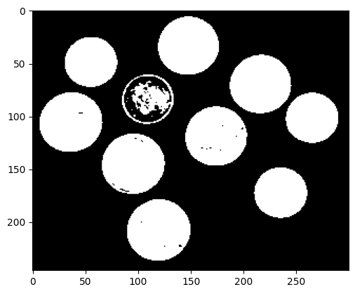

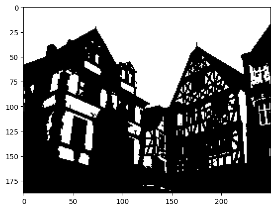

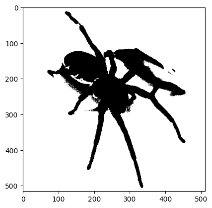

```python
import os
import numpy as np
import skimage as sk
import matplotlib.pyplot as plt

def otsu(image):
    hist, _ = np.histogram(image, bins=256, range=(0, 255)) # Histogramme de l'image
    hist_norm = hist / float(image.size) # Normalisation de l'histogramme
    variances = np.zeros(256) # Tableau des variances

    for t in range(256): # On parcours les seuils possibles
        q1 = np.sum(hist_norm[:t]) # Somme des probabilités des pixels de l'histogramme avant le seuil
        q2 = np.sum(hist_norm[t:]) # Somme des probabilités des pixels de l'histogramme après le seuil
        if q1 == 0 or q2 == 0: # Si l'une des deux sommes est nulle, on passe au seuil suivant
            continue
        mu1 = np.sum(np.arange(0, t) * hist_norm[:t]) / q1 # Moyenne des pixels avant le seuil
        mu2 = np.sum(np.arange(t, 256) * hist_norm[t:]) / q2 # Moyenne des pixels après le seuil
        variances[t] = q1 * q2 * (mu1 - mu2) ** 2

    return np.argmax(variances)

# Affiche toute les images pgm avec le seuil d'Otsu
for filename in os.listdir("./image"):
    if filename.endswith(".pgm"):
        image = sk.io.imread("./image/" + filename)
        seuil = otsu(image)
        image_seuillee = image > seuil
        plt.imshow(image_seuillee, cmap="gray")
        plt.show()
```

**Partie 2.** L’algorithme des moyennes mobiles (*k*-means) peut être utilisé pour regrouper les pixels d’une image couleur, et diminuer au final le nombre de couleurs présentes dans l’image.

Implémenter cet algorithme afin de réaliser cette tâche.

La fonction principale prendra en entréer une image couleur ou en niveau de gris et le nombre *k* de classe recherchée et retournera en sortie l’image composée, après traitement, de *k* couleurs.

```python
def imagekmeans(image, nbclasse):
    # Condition pour vérifier que l'image est bien en niveaux de gris ou en couleur
    if image.ndim == 2:
        pixels = image.reshape((-1, 1))
    elif image.ndim == 3:  # Image en couleur
        pixels = image.reshape((-1, 3))
    else:
        raise ValueError("L'image doit être en niveaux de gris (PGM) ou en couleur (3 canaux RVB).")

    # On initialise des centres de classes aléatoirement
    centres = np.random.randint(0, 256, (nbclasse, pixels.shape[1]))

    # On initialise un tableau de distances et un tableau de pixels associés à chaque classe
    distances = np.zeros((pixels.shape[0], nbclasse))
    classes_pixels = np.zeros(pixels.shape[0])

    # On initialise un tableau d'ancien centres pour la condition d'arrêt
    ancien_centres = np.zeros(centres.shape)

    # On initialise la condition d'arrêt qui est la distance entre les centres, quand elle est nulle c'est que les centres ne bougent plus
    deltacentres = np.linalg.norm(centres - ancien_centres)

    while deltacentres != 0:
        # on parcours les classes pour calculer les distances entre les pixels et les centres
        for i in range(nbclasse):
            distances[:, i] = np.linalg.norm(pixels - centres[i], axis=1)

        classes_pixels = np.argmin(distances, axis=1) # on récupère la classe du pixel le plus proche
        ancien_centres = np.copy(centres) # on sauvegarde les anciens centres

        # on calcule les nouveaux centres
        for i in range(nbclasse):
            # on vérifie si la moyenne des pixels de la classe contient des valeurs NaN ou infinies
            mean_pixels = np.mean(pixels[classes_pixels == i], axis=0)
            if np.isnan(mean_pixels).any() or np.isinf(mean_pixels).any():
                mean_pixels = np.mean(pixels, axis=0)
            centres[i] = mean_pixels

        deltacentres = np.linalg.norm(centres - ancien_centres) # on calcule la distance entre les nouveaux centres et les anciens pour la condition d'arrêt

    # on crée un tableau de pixels rempli de zéros
    new_pixels = np.zeros(pixels.shape)

    # on remplit le tableau de pixels avec les couleurs des centres correspondants
    for i in range(nbclasse):
        new_pixels[classes_pixels == i] = centres[i]

    # on remet les pixels dans la forme de l'image d'origine
    if image.ndim == 2:
        new_image = new_pixels.reshape(image.shape).astype('uint8')
    else:
        new_image = new_pixels.reshape(image.shape).astype('uint8')

    # Retourne deux tableaux, le premier est l'image avec les couleurs des centres, le deuxième est les centres
    return new_image, centres
```

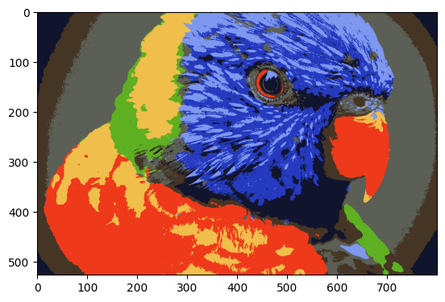

```python
image = os.path.join("./image", "perr.jpg")
image8color = imagekmeans(sk.io.imread(image), 8)[0]
# Affiche l'image avec 8 couleurs
plt.imshow(image8color)
plt.show()
```

**Partie 3.** Tester votre algorithme du *k*-means sur des images noir et blanc. Que donne votre algorithme lorsque vous tentez de trouver deux clusters seulement (est-ce mieux ou moins bien qu’Otsu) ?

```
Image avec otsu :
```

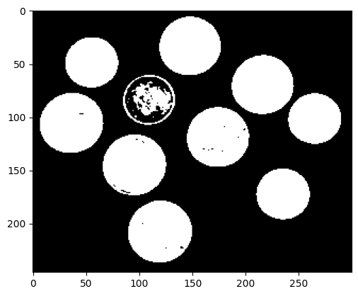

```
Image avec kmeans :
```

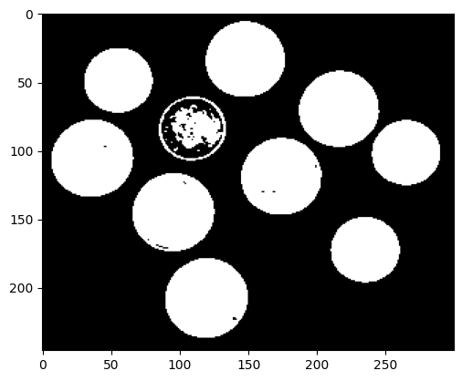

```
Image avec otsu :
```

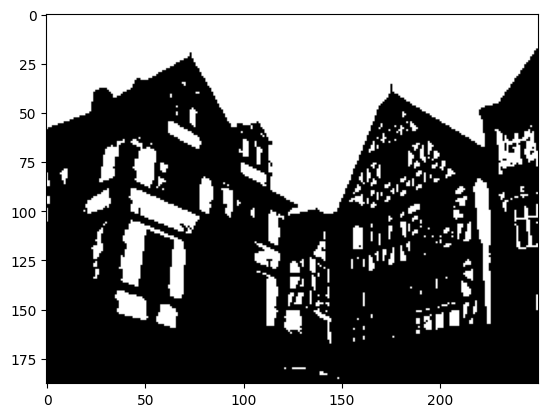

```
Image avec kmeans :
```

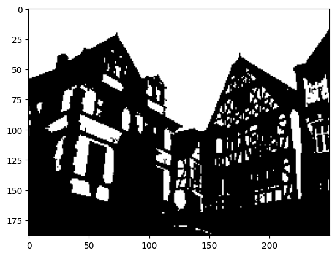

```
Image avec otsu :
```

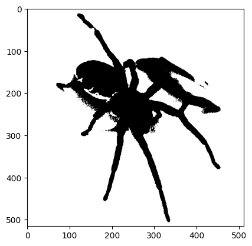

```
Image avec kmeans :
```

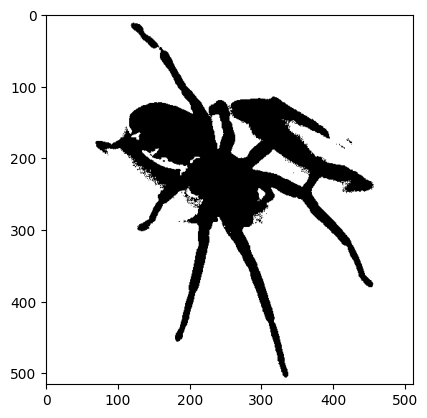

```python
# Comparé otsu avec kmeans sur toute les images pgm
for filename in os.listdir("./image"):
    if filename.endswith(".pgm"):
        image = sk.io.imread("./image/" + filename)
        seuil = otsu(image)
        image_seuillee = image > seuil
        image_kmeans = imagekmeans(image, 2)[0]
        print("Image avec otsu : ")
        plt.imshow(image_seuillee, cmap="gray")
        plt.show()
        print("Image avec kmeans : ")
        plt.imshow(image_kmeans, cmap="gray")
        plt.show()
```

Comme on peut le voir sur les images, les rendus sont très proches on peut noter quelque très subtilles différences à certain endroit ou kmeans arrive à retirer un peu plus de bruit que otsu.

**Partie 4.** Un problème avec l’algorithme du k-means est qu’il faut connaître le nombre de clusters que l’on souhaite obtenir...

Pour tenter d’évaluer si le nombre de clusters est bon ou pas, on pourrait répéter plusieurs fois l’algorithme et voir si les attributions de groupes sont stables d’une itération à une autre. Si elles ne le sont pas, il y a de fortes chances que le nombre de clusters soit trop bas/élevé.

Tester cette hypothèse sur les images `Mimi1` (à peu près 10-12 couleurs), `Mimi2` (entre 10 et 12 couleurs), `Mimi3`(entre 8 et 11 couleurs) et `Caillou`(entre 8 et 10 couleurs).  
Les résultats sont-ils stables lorsque le nombre de clusters est très bas/très grand/proche de la réalité ? Pouvez-vous proposer une mesure de stabilité permettant de quantifier si un nombre de cluster choisi est pertinent ?

```python
# Fonction pour trouver le meuilleur nombre de classes avec imagekmeans
def best_nb_cluster(image):
    cluster = 2
    best_cluster = 2
    best_score = 0
    while cluster <= 16:
        image_cluster = imagekmeans(image, cluster)[0]
        score = np.sum(image_cluster == image)
        if score > best_score:
            best_score = score
            best_cluster = cluster
        cluster += 1
    return best_cluster

# Fonction pour tester l'image que l'on veut avec imagekmeans et l'afficher
def imageandcluster(nameofimage):
    image = os.path.join("./image", nameofimage)
    nbcluster = best_nb_cluster(sk.io.imread(image))
    image_cluster = imagekmeans(sk.io.imread(image), nbcluster)[0]
    print("Le meilleur nombre de classes pour " + nameofimage + " est : " + str(nbcluster))
    plt.imshow(image_cluster)
    plt.show()
```

#### Test pour chaque image :

mimi1.jpg

```
Le meilleur nombre de classes pour mimi1.jpg est : 12
```

[figure not shown]

```python
imageandcluster("mimi1.jpg")
```

mimi2.jpg

```
Le meilleur nombre de classes pour mimi2.jpg est : 11
```

[figure not shown]

```python
imageandcluster("mimi2.jpg")
```

mimi3.jpg

```
Le meilleur nombre de classes pour mimi3.jpg est : 10
```

[figure not shown]

```python
imageandcluster("mimi3.jpg")
```

- Les résultats peuvent être assez aléatoires, quand il est très bas, il y a forcément une perte de qualité, on voit que des couleurs ne sont pas logiques, quand il est très grand par contre on ne vois pas du tout la différence, car il y a plus de clusters donc pas de perte de qualité. Et pour finir quand le nombre de clusters est proche de la réalité, c'est assez impressionnant de voir qu'avec une dizaine de couleur, on obtient des résultats si bons, on pourrait difficilement déceler la différence malgré le peu de couleur (en-tout-cas ça marche bien pour une image de dessin animé, ça marche beaucoup moins bien pour le perroquet évidemment).
- Oui, on peut tester différents clusters et comparée à l'image d'origine pour définir un nombre entre 0 et 1 (0 n'étant pas du tout fidèle et 1 image identique) et pouvoir déterminer si un nombre de clusters est pertinent ou non en fonction de chaque image.